# Forest Plots

# Forest Plots

```r
knitr::opts_knit$set(root.dir = "../../")
```

```r
suppressPackageStartupMessages(library(tidyverse))
library(gt)
library(targets)
source("src/R/forest_plots.R")
```

```r
df_forest <- tar_read(df_forest)

df_forest
```

```
## # A tibble: 4 × 2
##   category_id tab
##   <chr>       <list>
## 1 cnsn        <gt_tbl [15]>
## 2 dtin        <gt_tbl [15]>
## 3 sfty        <gt_tbl [15]>
## 4 ptpe        <gt_tbl [15]>
```

## Consent

```r
df_forest %>%
  filter(category_id == "cnsn") %>%
  pull(tab) %>%
  htmltools::tagList()
```

Consent Related Audit and Inspection Findings

Adjusted Risk Factors

Distribution

N<sup>1</sup>

N with Findings<sup>1</sup>

Coefficient (CI95)<sup>2</sup>

Odds Ratio (CI95)

P

Coefficient Over Time (CI95)<sup>2,3</sup>

# Issues Late

[0 - 4)

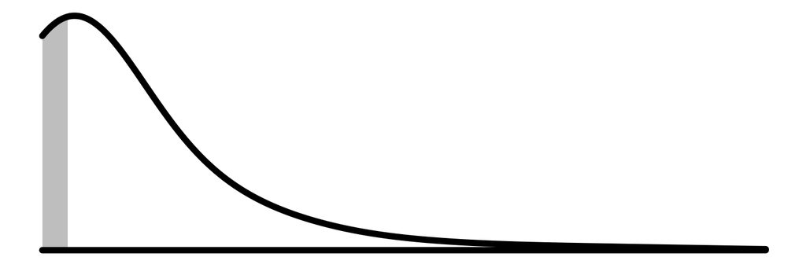

172 (21.2%)

60 (34.9%)

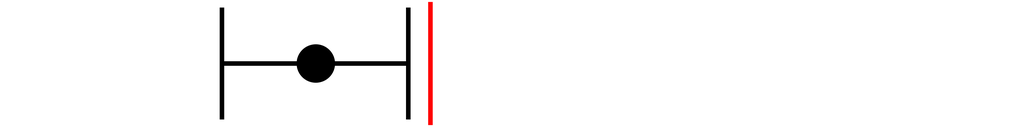

0.6 (0.4-0.9)

0.01577 *

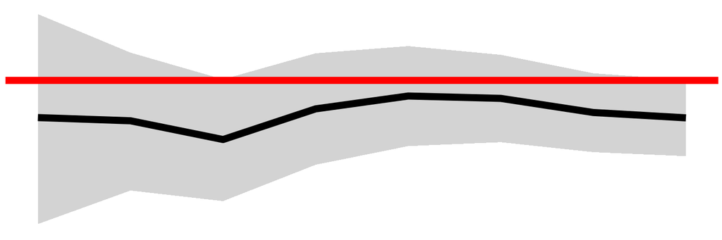

[4 - 8)

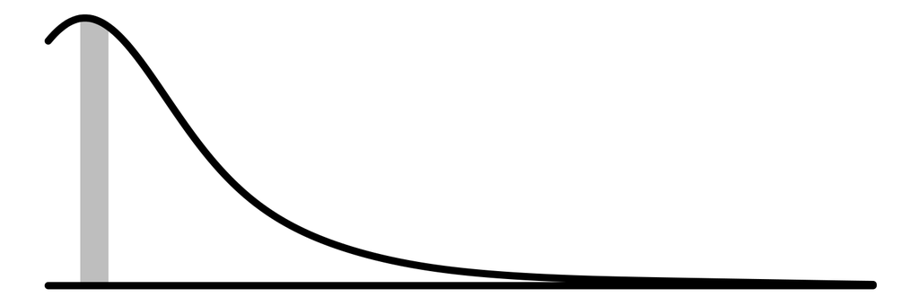

85 (10.5%)

33 (38.8%)

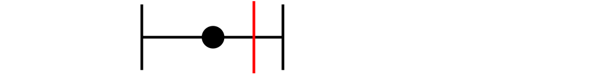

0.7 (0.5-1.2)

0.2554

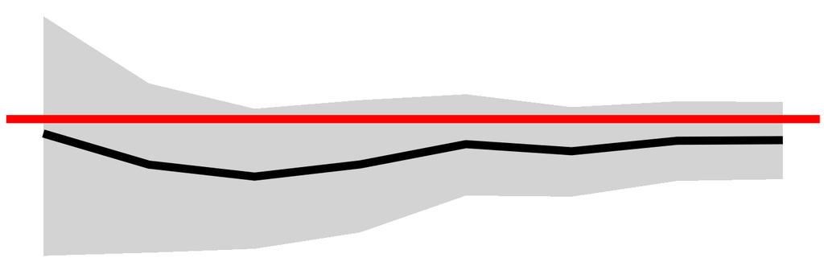

[8 - 14)

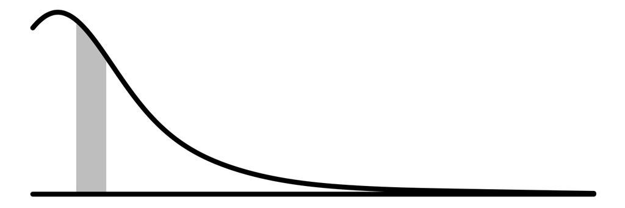

60 (7.4%)

28 (46.7%)

[14 - 30)

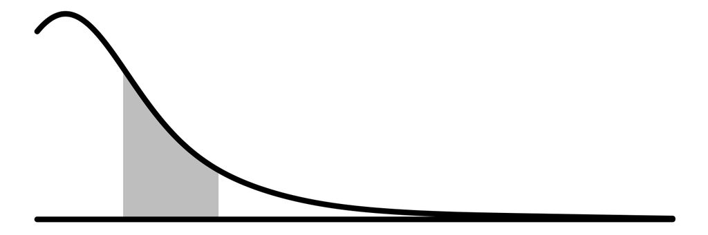

71 (8.8%)

35 (49.3%)

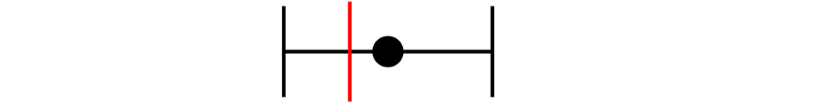

1.2 (0.7-2.1)

0.47143

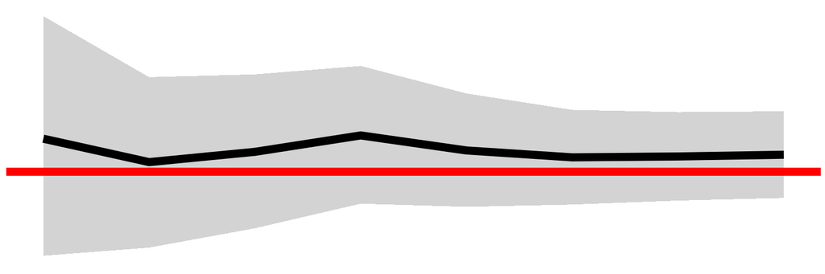

[30 - Inf)

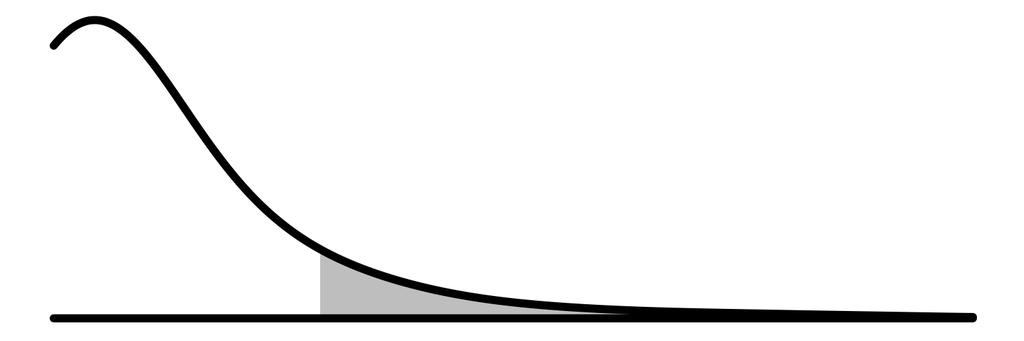

47 (5.8%)

27 (57.4%)

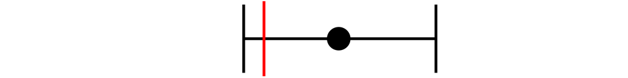

1.7 (0.9-3.2)

0.12573

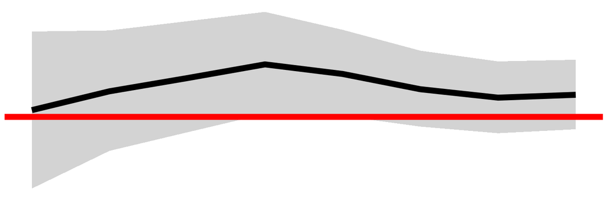

missing

376 (46.4%)

188 (50%)

# Minor Deviations Per Days on Study<sup>4</sup>

[0 - 0.0029)

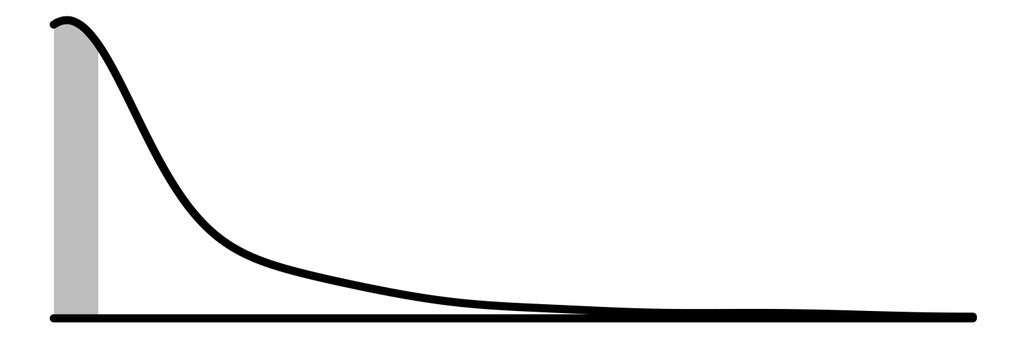

281 (34.6%)

111 (39.5%)

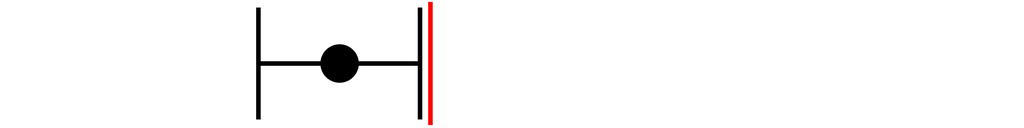

0.7 (0.5-1)

0.0274 *

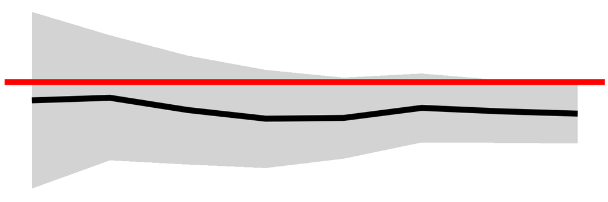

[0.0029 - Inf)

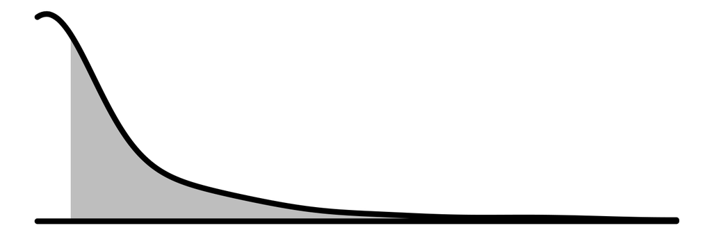

147 (18.1%)

68 (46.3%)

missing

383 (47.2%)

192 (50.1%)

Pediatric Study

Not Pediatric Study

756 (93.2%)

335 (44.3%)

Pediatric Study

55 (6.8%)

36 (65.5%)

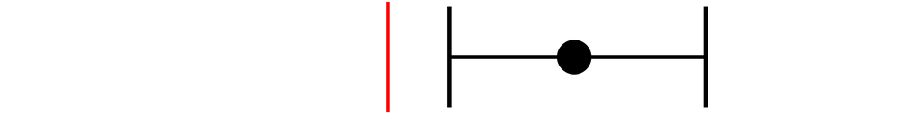

2.4 (1.3-4.4)

0.00421 **

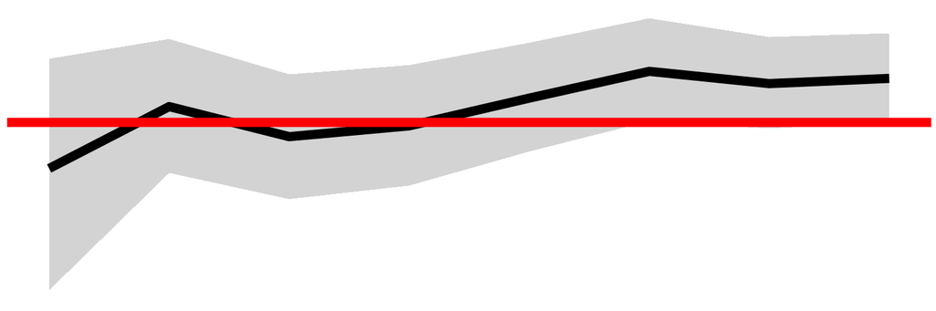

missing

0 (0%)

0 (0%)

Perc Visits Not Occured (Percent Rank)<sup>5</sup>

[0 - 0.5)

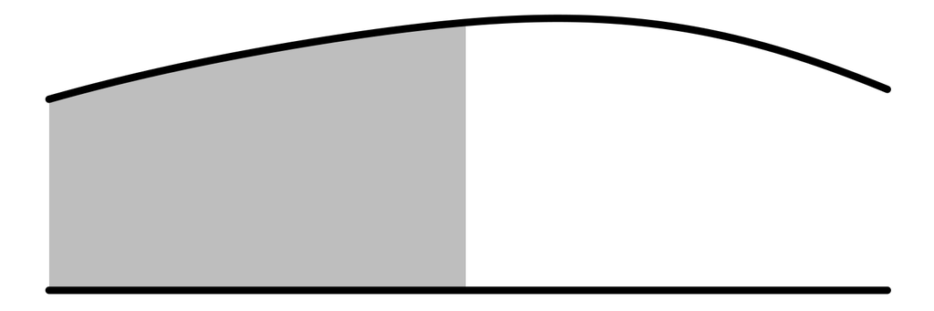

157 (19.4%)

59 (37.6%)

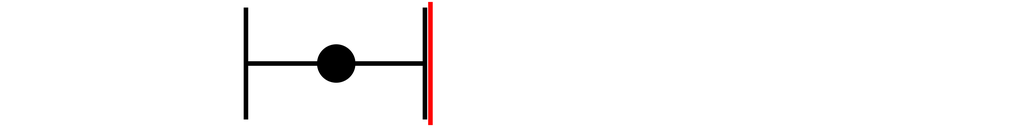

0.7 (0.5-1)

0.03882 *

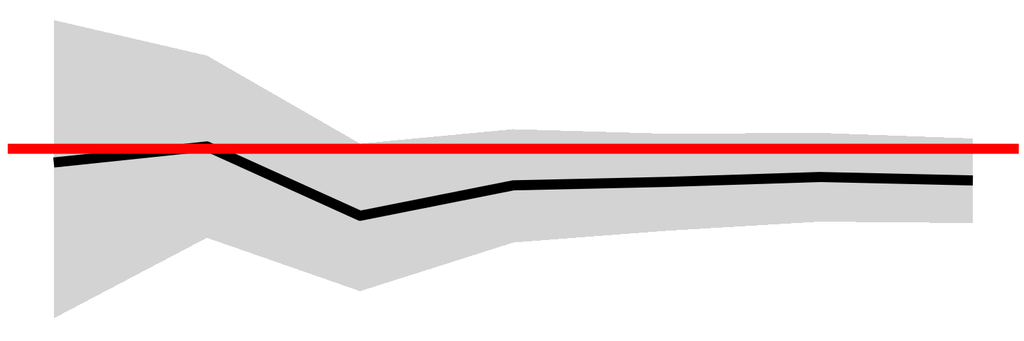

[0.5 - 0.85)

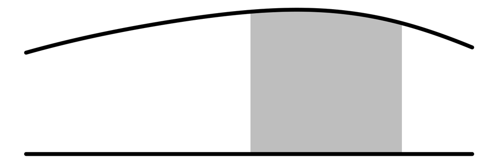

131 (16.2%)

59 (45%)

[0.85 - Inf)

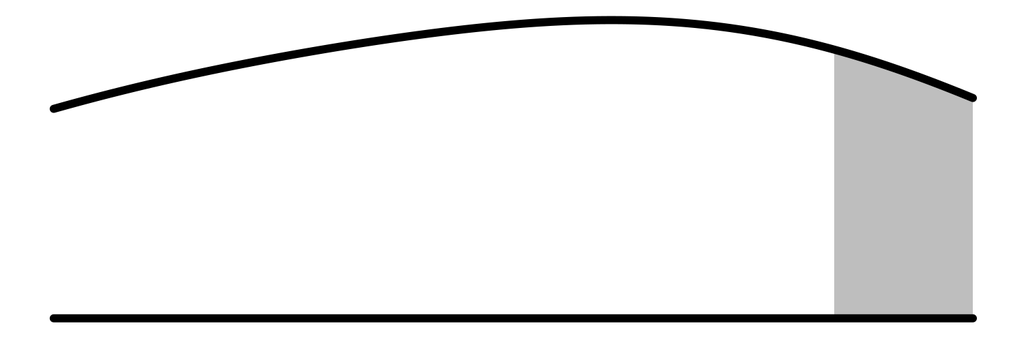

67 (8.3%)

33 (49.3%)

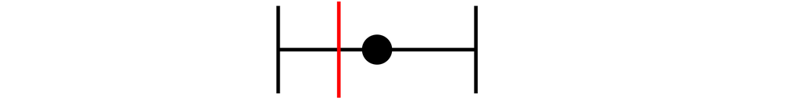

1.2 (0.7-2.1)

0.44656

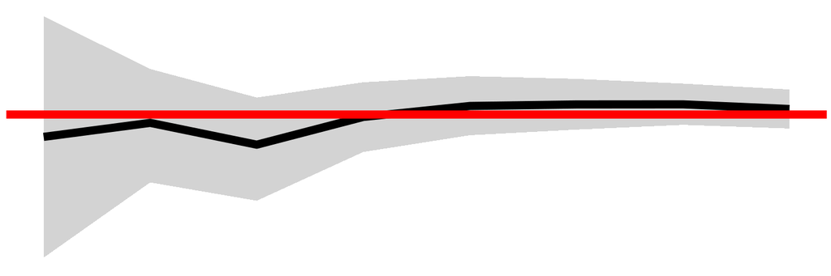

missing

456 (56.2%)

220 (48.2%)

Total Population<sup>6</sup>

[8.16 thous. - 8.1 mil.)

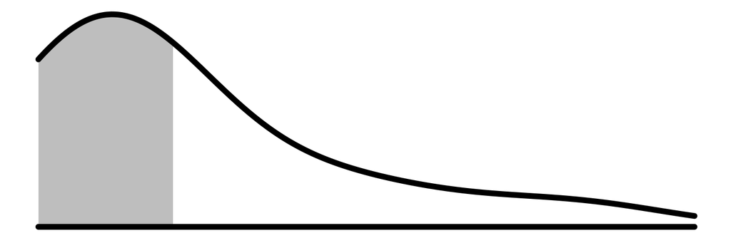

436 (53.8%)

180 (41.3%)

[8.1 mil. - Inf)

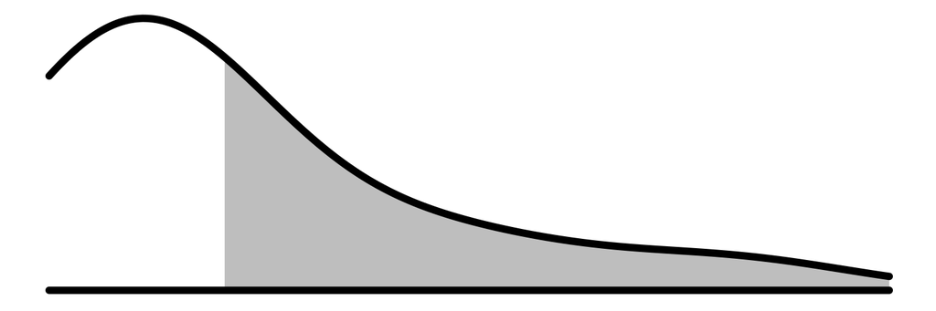

205 (25.3%)

117 (57.1%)

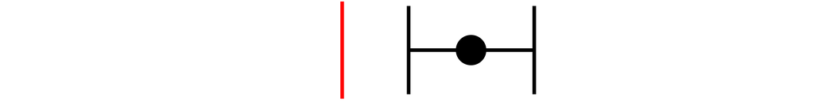

2 (1.4-2.8)

6e-05 ***

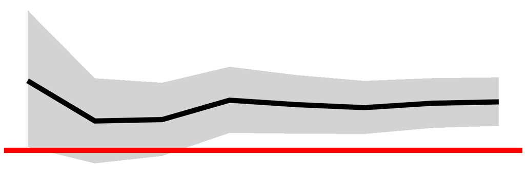

missing

170 (21%)

74 (43.5%)

<sup>*1*</sup> Number of Clinical Trial Site Audits and Inspections

<sup>*2*</sup> Red Reference Line Indicates Zero

<sup>*3*</sup> Coefficient Value as New Data is Successively Added from 2011-2019

<sup>*4*</sup> Sum of Days Since Enrollment of All Patients

<sup>*5*</sup> Percent Rank of Site Within Study

<sup>*6*</sup> Population Within 100 km Radius of Site